# Vision for Data Science Education

June 6, 2017

## How to build a successful Data Science education program:

teach responsible use of methods, tools and workflows

keep the curriculum current and modern

build integrated content from the founding fields

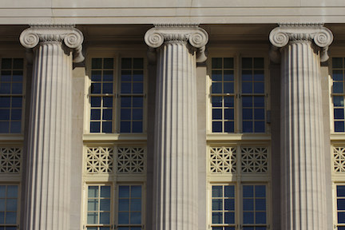

source: [Rich Renomeron](https://flic.kr/p/k4Cwwx) [CC BY-NC-ND](https://creativecommons.org/licenses/by-nc-nd/2.0/)

## 1. Teach responsible use of Data Science methods, tools and workflows

balance the depth and breadth of content to teach

teach reproducible Data Science workflows

## 1.1 Balancing the depth and breadth of content to teach

teach what is needed for a typical Data Science workflow

ensure students have enough knowledge to use in correct context, and to correctly interpret results

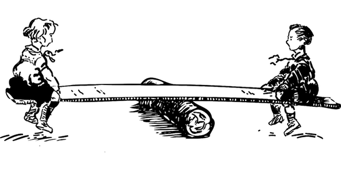

## Typical Data Science workflow is a lot of things!

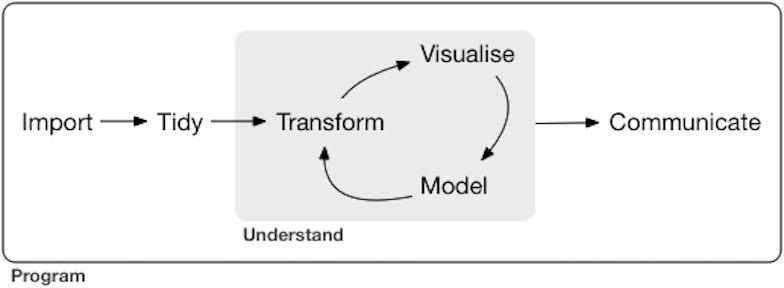

source: [R for Data Science](http://r4ds.had.co.nz/introduction.html) by Grolemund & Wickham

## 1.2 Teach reproducible Data Science workflows

reproducible workflows lead to transparency, rigour and believability of Data Science analysis and visualization

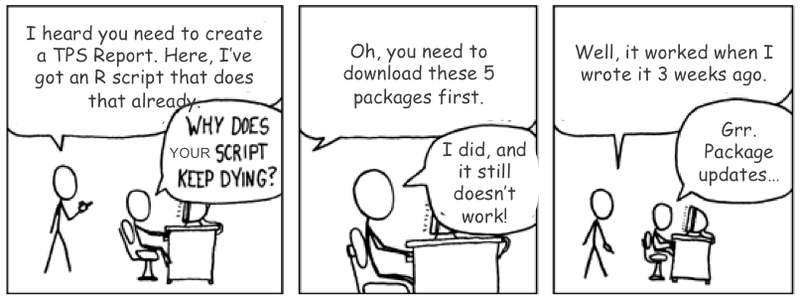

source: [xkcd](https://xkcd.com/)

## Essential skills for reproducibility

[figure not shown]

source: [Sidney Harris](http://www.sciencecartoonsplus.com/pages/gallery.php/)

We need to explicitly teach students:

scripting & literate programming

version control

package use & development

package management

environment management

automation

## 2. Keeping the Data Science curriculum current and modern

Data Science in one of the most rapidly evolving fields

Instructors need to stay current

Students must learn how to stay current too!

## How we can stay current (beyond the literature):

Read Data Science, Tech and business blogs

Use social media

Attend Data Science-related conferences

Communicate with Industry

Watch what other programs are doing

[figure not shown]

## 3. Building integrated content from the founding fields of Data Science

Data Science education is best created by collaboration

Data Science initiatives can benefit supporting departments

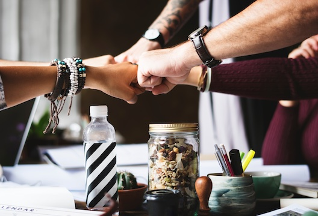

## Summary - 3 pillars of Data Science Education

teach responsible use of methods, tools and workflows

keep the curriculum current and modern

build integrated content from the founding fields

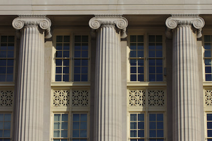

source: [Rich Renomeron](https://flic.kr/p/k4Cwwx) [CC BY-NC-ND](https://creativecommons.org/licenses/by-nc-nd/2.0/)